# e-메탄올 정제용 메탄올–물 증류탑 설계

Separation Process · Team project: Column Design

분리공정 3조

2026-11-01

## 발표 흐름

1. **Choice of System and Separation Method** · e-메탄올과 물 분리
2. **Method Implementation (and Test)** · McCabe–Thiele 코드, Example 21.2로 검증
3. **Problem Statement / Specification** · 20 t/h, $x_D \ge 0.9983$, $x_B \le 0.001$
4. **Design** · McCabe–Thiele → DWSIM 엄밀 계산 → 단수–환류비
5. **Other Considerations** · 체판 수력학, 효율, 압력강하, TAC
6. **최종 설계안과 한계**

**설계 질문**

- 목표 조성 달성에 필요한 이론단수·환류비는?
- McCabe–Thiele 예비 설계를 DWSIM에 넣으면 조성·열부하는 어떻게 바뀌나?
- 실제 체판 몇 장, 탑경·높이는? 비용 최소 조건은?

# Choice of System and Separation Method

## 메탄올의 산업적 중요성

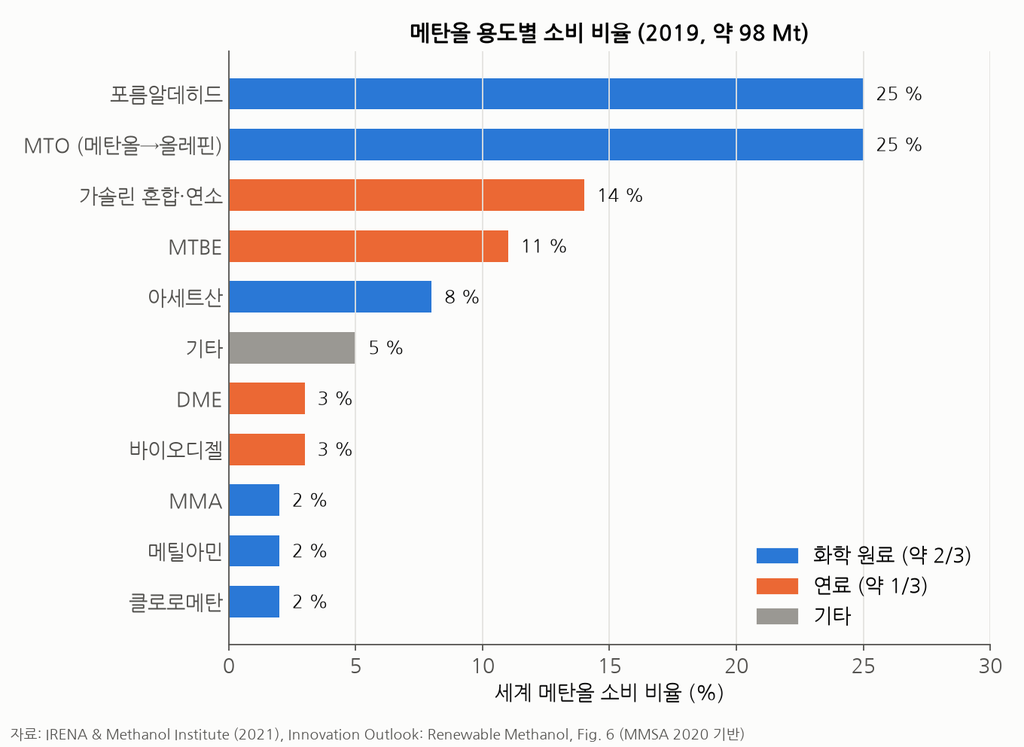

- 에틸렌·프로필렌·암모니아와 함께 **4대 기초 화학물질** — 다른 화학제품 생산의 출발 원료
- 세계 생산 **약 98 Mt/년 (2019)**, 10년 사이 약 2배 (증가분 대부분 중국 석탄 기반)
- 수요 전망: 2025년 120 Mt 이상, 2050년 **500 Mt** (IRENA Transforming Energy Scenario)
- 원료: 천연가스 ~65 %, 석탄 ~35 %, 바이오·재생 **< 1 %**
- 생애주기 배출 **0.3 Gt CO₂/년** = 화학·석유화학 부문 배출의 약 10 %
- 화석 메탄올 생산비 100–250 USD/t

IRENA & Methanol Institute (2021), *Innovation Outlook: Renewable Methanol*, Key findings pp. 4–5, p. 12, Fig. 6 p. 23

## 왜 e-메탄올인가 · 증류가 왜 중요한가

**재생 메탄올 두 가지 경로**

- 바이오메탄올: 폐목재·농업 부산물·바이오가스·도시 고형폐기물·흑액
- **e-메탄올**: 그린 수소 + 포집 CO₂ (BECCS, DAC) — 기존 합성 공정과 사실상 같은 상용 기술

| 구분 | 생산비 (USD/t) |
| --- | --- |
| 화석 메탄올 | 100–250 |
| e-메탄올 (현재, BECCS CO₂) | 800–1,600 |
| e-메탄올 (현재, DAC CO₂) | 1,200–2,400 |
| e-메탄올 (2050 전망) | 250–630 |

재생 메탄올 생산은 연 0.2 Mt 미만 (2021 보고서 기준) → 규모 확대 초기 단계

**상용화 사례**

- 2025.5 덴마크 Kassø: 첫 대규모 상업 e-메탄올 플랜트, **연 42,000 t**, 304 MW 태양광 + 바이오 CO₂, 탄소발자국 최대 97 % 저감 → Maersk 선박 연료, LEGO·Novo Nordisk 원료
- 해운 연료: Maersk 메탄올 이중연료 대형 컨테이너선 12척 인도 완료 (2025.6, HD현대중공업 건조)

**증류와의 연결** · $\mathrm{CO_2 + 3H_2 \rightarrow CH_3OH + H_2O}$ → 조메탄올에 물 약 36 wt%

본 설계 기준 재비기 열 **약 2.2 GJ/t-메탄올**, 정제비 (TAC) **약 30 USD/t** → e-메탄올 생산비의 약 2–4 %. 스팀을 화석 연료로 만들면 탄소발자국에도 직접 반영

IRENA & MI (2021) pp. 4–5 · European Energy 보도자료 (2025.5.13) · Maritime Executive (2025.6)

## 왜 메탄올–물인가 · e-메탄올 정제

- CO₂ 수소화: $\mathrm{CO_2 + 3H_2 \rightarrow CH_3OH + H_2O}$
- 메탄올 1 mol당 물 1 mol 생성 → 조메탄올의 물 **약 36 wt%**
- 제품 규격 (IMPCA): 물 **≤ 0.100 wt%**
- 메탄올 끓는점 64.7 °C, 물 100 °C → 상압 **연속 증류** 1기로 분리

```
 CO2 + H2 → [반응기] → 조메탄올 (x_F = 0.50)
                          │
                    ┌─────┴─────┐
                    │  증류탑    │ → 탑정: 메탄올 (x_D ≥ 0.9983)
                    │ 101.3 kPa │
                    └─────┬─────┘
                          └──→ 탑저: 물 (x_B ≤ 0.001)
```

| 물성 | 메탄올 (A) | 물 (B) |
| --- | --- | --- |
| CAS | 67-56-1 | 7732-18-5 |
| 몰질량 (g/mol) | 32.0419 | 18.0153 |
| 정상 끓는점 (K) | 337.8 | 373.17 |
| 몰 기화잠열 (kJ/mol) | 35.21 | 40.65 |
| Antoine $a,b,c$ (bar, K) | 5.20409, 1581.341, −33.50 | 5.07680, 1659.793, −45.854 |

NIST Chemistry WebBook. Antoine 식 $\log_{10}P' = a - b/(T+c)$; 355 K 이상에서는 고온 구간 계수 사용.

## 비이상 VLE와 물성 모델 선정

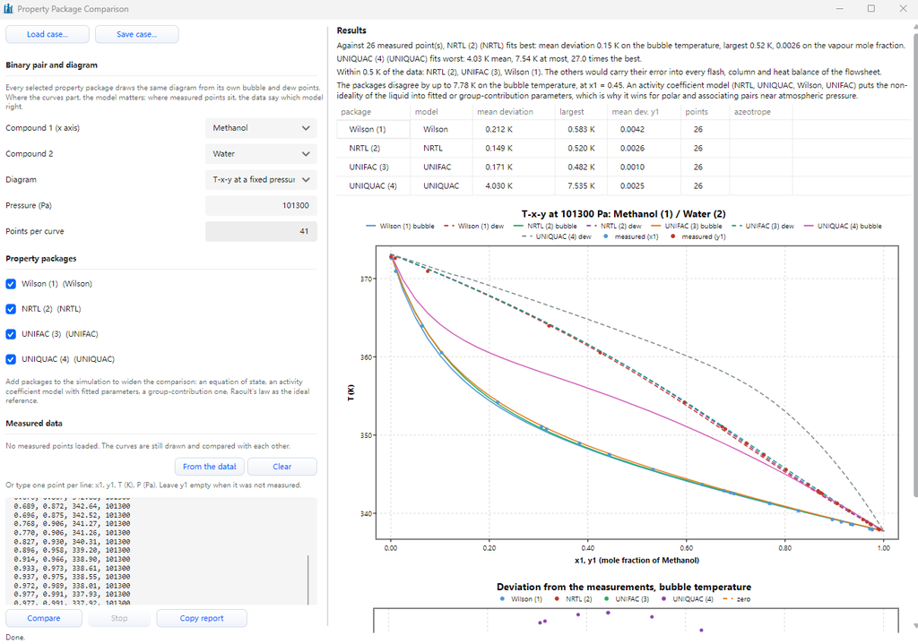

실측 26점 (Álvarez 등 2011, 101.3 kPa) vs DWSIM 모델

| 모델 | $T_{bub}$ 평균오차 (K) | 최대오차 (K) | $y_e$ 평균오차 |
| --- | --- | --- | --- |
| Wilson | 0.212 | 0.583 | 0.0042 |
| NRTL | **0.149** | 0.520 | 0.0026 |
| UNIFAC | 0.171 | **0.482** | **0.0010** |
| UNIQUAC | 4.030 | 7.535 | 0.0025 |

**UNIFAC 채택** · McCabe–Thiele 작도에 직접 쓰는 값은 $y_e$ → $y_e$ 오차 최소 모델 선택. 공비점 없음, $y_e > x_e$ 전 구간.

# Method Implementation (and Test)

## McCabe–Thiele 코드 구현 · Example 21.2로 테스트

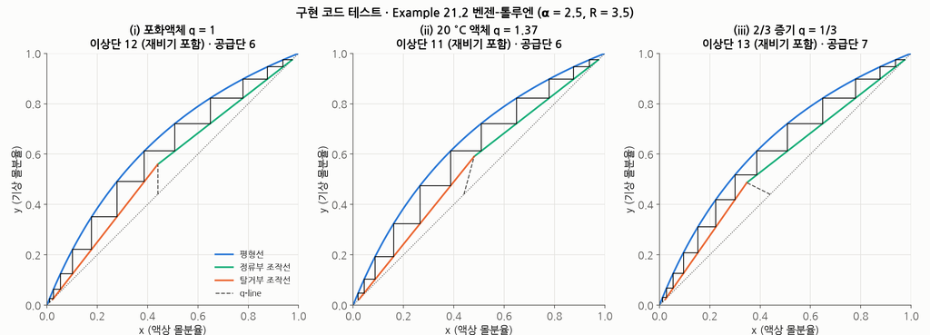

| 항목 | 강의자료 풀이 | 구현 코드 |
| --- | --- | --- |
| $x_F, x_D, x_B$ | 0.440, 0.974, 0.0235 | 0.440, 0.974, 0.0235 |
| $D$ / $B$ (kmol/h) | 153.4 / 196.6 | 153.1 / 196.4 |
| $N_{min}$ (Fenske, α = 2.5) | — | 8.04 (재비기 포함) |
| $R_{Dm}$ (i) / (ii) / (iii) | — | 1.400 / 1.165 / 2.135 |
| $R_{Dm}$ (i), Wagner 식 + Raoult | 1.245 (안내문 예시) | 1.421 |

- 계단 작도: 탑정부터, 교점 통과 시 탈거부로 전환 (최적 공급단)
- 평형곡선을 바꿔도 (i) 이상단 12 · 공급단 6 동일: Raoult + Antoine $R_{Dm}$ = 1.422, Wagner 식 = 1.421
- 안내문 1.245는 핀치 $y' = 0.678$ ($\alpha \approx 2.68$)에 해당 → 평형곡선 차이로는 재현 안 됨
- $R_{Dm}$은 핀치점 $y'$에 민감: $\partial R_{Dm}/\partial y' \approx -11$ → 평형곡선 출처를 명시해야 함

## 같은 코드로 DWSIM 작도 재현

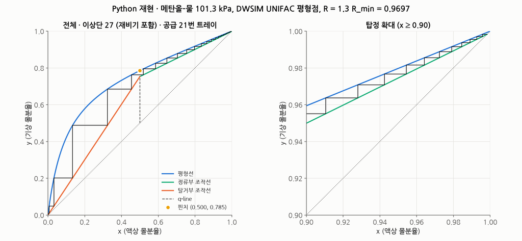

| 항목 | DWSIM McCabe–Thiele | Python (DWSIM UNIFAC 224점) |
| --- | --- | --- |
| $R_{Dm}$ · 핀치점 | 0.7459 · (0.500, 0.7854) | 0.7459 · (0.500, 0.7854) |
| $N_{min}$ (전환류) | 10 | 10 |
| $R_D = 1.3R_{Dm} = 0.9697$ | 26 트레이 + 재비기, 공급 21번 | 26 트레이 + 재비기, 공급 21번 |

# Problem Statement / Specification

## 설계 조건

| 항목 | 설계 기준 |
| --- | --- |
| 물성 모델 | UNIFAC (DWSIM 9) |
| 압력 | 탑정 101.3 kPa(abs) (예비 계산은 ΔP = 0) |
| 공급 | 20,000 kg/h, $x_F = 0.50$, 포화액체 $q = 1$ |
| 탑정 | $x_D \ge 0.9983$ → 물 0.0957 wt% (< IMPCA 0.100) |
| 탑저 | $x_B \le 0.001$ → 메탄올 0.178 wt% |
| 장치 | 전응축기 + 부분재비기, 체판탑 |

**물질수지** $F = D + B$, $\;Fx_F = Dx_D + Bx_B$

| 흐름 | kmol/h |
| --- | --- |
| $F$ | 799.09 |
| $D$ | 399.82 |
| $B$ | 399.26 (110.906 mol/s) |

메탄올 회수율 $Dx_D/Fx_F \approx$ **99.90 %**

처음엔 $x_D = 0.995$로 잡았으나 물 0.282 wt% → IMPCA 초과 → **0.9983**으로 상향

# Design · 이론단과 환류비

## McCabe–Thiele 예비 설계 (DWSIM, UNIFAC)

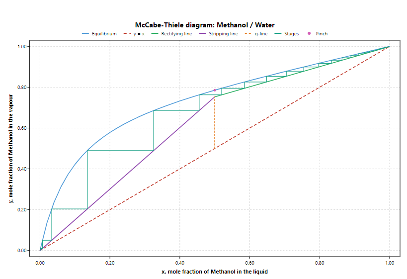

| 항목 | 결과 |
| --- | --- |
| $R_{Dm}$ | 0.7459 |
| $R_D = 1.3R_{Dm}$ | 0.9697 |
| $N_{min}$ | 10 |
| 이론단수 | 26 트레이 + 재비기 = 27 |
| 공급단 | 탑정에서 21번째 |

$$R_{Dm} = \frac{x_D - y'}{y' - x'} = \frac{0.9983 - 0.7854}{0.7854 - 0.500}$$

정류부 조작선 $y = 0.4923x + 0.5068$, 교점 (0.500, 0.7530)

## DWSIM 엄밀 계산 · 사양 충족 환류비 찾기

28 위치 (전응축기 + 26 트레이 + 재비기), 공급 22, $B$ = 110.906 mol/s 고정 → $R_D$ 이분법

| $R_D$ | $x_D$ | $x_B$ | 판정 |
| --- | --- | --- | --- |
| 0.96970 | 0.997914 | — | 탑정 미달 |
| 1.00000 | 0.998403 | 0.000892 | 충족 |
| 0.99250 | 0.998298 | 0.000998 | 탑정 미달 |
| **0.99264** | **0.998300** | **0.000996** | **충족** |

탑저 사양이 먼저 충족 → **탑정 조성이 환류비 결정**

**CMO 가정 점검** (단별 엔탈피 수지)

| 구간 | 몰유량 변화 |
| --- | --- |
| 정류부 $L$, Stage 2 → 21 | 110.19 → 100.81 mol/s (−8.5 %) |
| 탈거부 $V$, Stage 22 → 27 | 211.88 → 194.81 mol/s (−8.1 %) |

**열부하** ($R_D$ = 0.99264): $q_c$ = 7,843 kW, $q_r$ = 7,979 kW

$FH_F + q_r = DH_D + BH_B + q_c$ → $q_r - q_c$ = 135.62 kW 일치

몰 잠열 차이 (35.2 vs 40.7 kJ/mol) → CMO 붕괴 → 작도값 0.9697로는 미달, **0.99264** 필요

## 단수 ↔︎ 환류비 ↔︎ 열부하

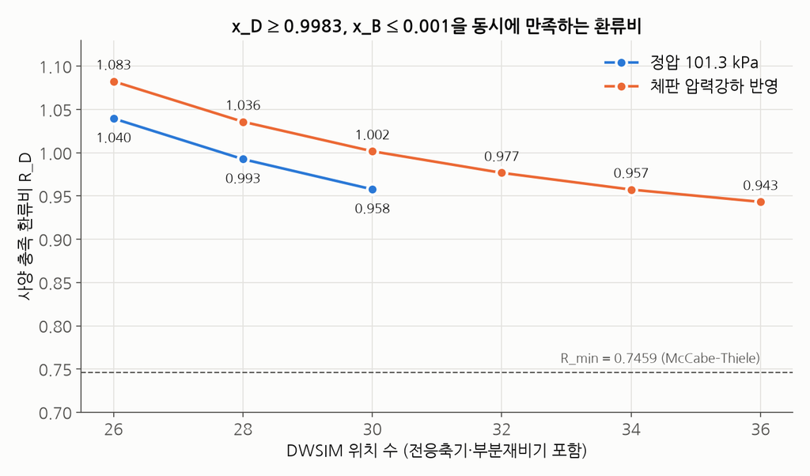

정압 101.3 kPa, 사양 충족 경계

| DWSIM 위치 | 공급 | $R_D$ | $q_c$ (kW) | $q_r$ (kW) |
| --- | --- | --- | --- | --- |
| 26 | 20 | 1.03967 | 8,028 | 8,164 |
| 28 | 22 | 0.99264 | 7,843 | 7,979 |
| 30 | 24 | 0.95775 | 7,706 | 7,842 |

- 26 → 28: $q_r$ −185 kW (−2.27 %), 28 → 30: −137 kW (−1.72 %) → **수확 체감**
- 체판 ΔP 반영 시 탑저 압력·온도 상승 → 같은 위치에서 $R_D$ +0.04 내외

# Other Considerations

## 체판탑 설계 · Example 21.6 방식 (탑정 트레이)

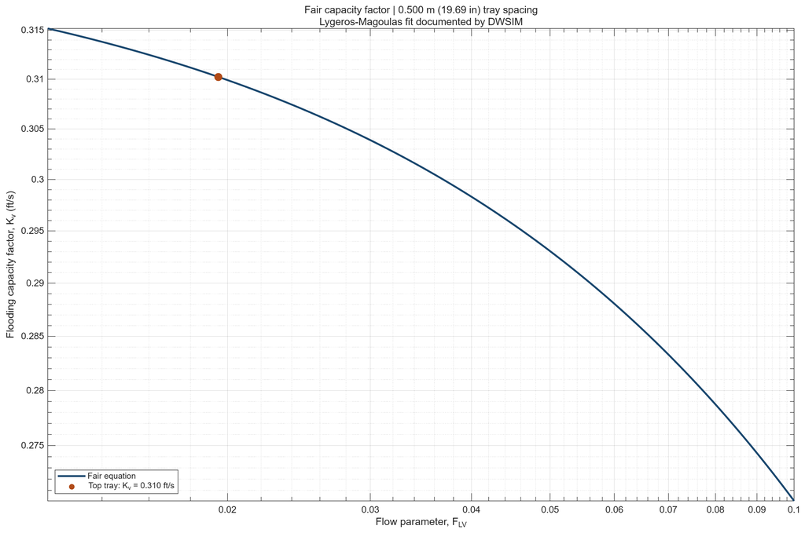

트레이 간격 0.500 m, Stage 2 물성: $\rho_V$ 1.155, $\rho_L$ 754.9 kg/m³, σ 19.06 dyn/cm. 구멍 1/4 in, 피치 3/4 in, 위어 2 in.

$F_{LV} = \dfrac{R_D}{1+R_D}\sqrt{\rho_V/\rho_L} = 0.0195$ → $K_v$ = 0.310 ft/s (Fair)

$u_c = K_v\sqrt{(\rho_L-\rho_V)/\rho_V}\,(\sigma/20)^{0.2}$ = 2.393 m/s

| 항목 | 한계 속도 기준 | **80 % 운전 (설계)** |
| --- | --- | --- |
| 기체 속도 (m/s) | 2.393 | 1.914 |
| 기포 면적 $A_b$ (m²) | 2.564 | 3.205 |
| 탑경 $D_c$ (m) | 2.160 | **2.415** |
| 단당 ΔP (kPa) | 0.894 | 0.670 |
| 다운커머 froth $Z$ (mm) | 337.8 | 276.1 |

$Z$ = 276 mm < 트레이 간격 500 mm → **다운커머 flooding 없음** (Stage 2–27 전체 점검, 최대 Stage 2)

## 트레이 효율과 실제 단수

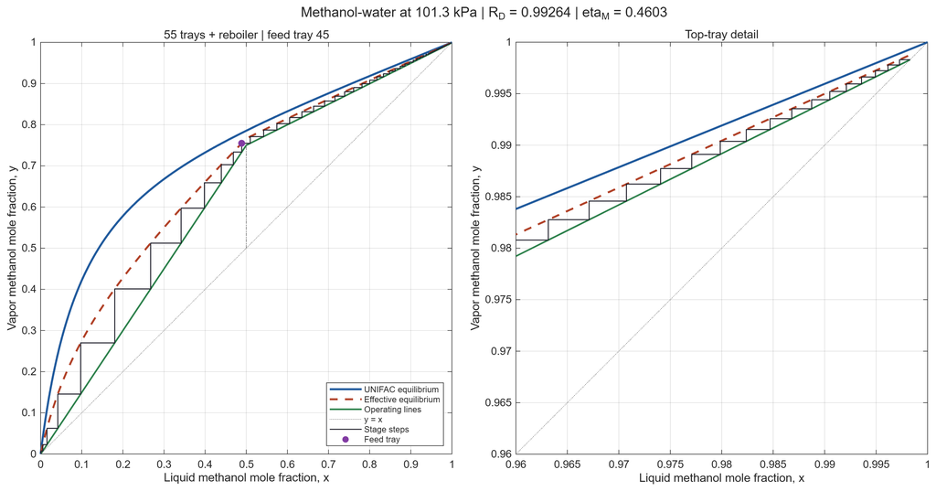

**O’Connell** · $\bar\alpha = (2.479 \times 3.660 \times 7.977)^{1/3} = 4.167$, $\mu_L$ = 0.315 cP

$\eta_0 = 0.492(\mu_L\bar\alpha)^{-0.245}$ = **0.4603** → 26/0.4603 → **57장**

**Murphree 유효 평형선** $y_e' = y + \eta_M(y_e - y)$

| $\eta_M$ | 실제 트레이 | 공급 트레이 |
| --- | --- | --- |
| 0.4103 | 62 | 50 |
| **0.4603** | **55** | **45** |
| 0.5103 | 50 | 40 |

효율 ±0.05 → 트레이 −5 / +7장. 높이 (55–57장): 29–31 m

## DWSIM 검증 · 효율 + 압력강하 적용

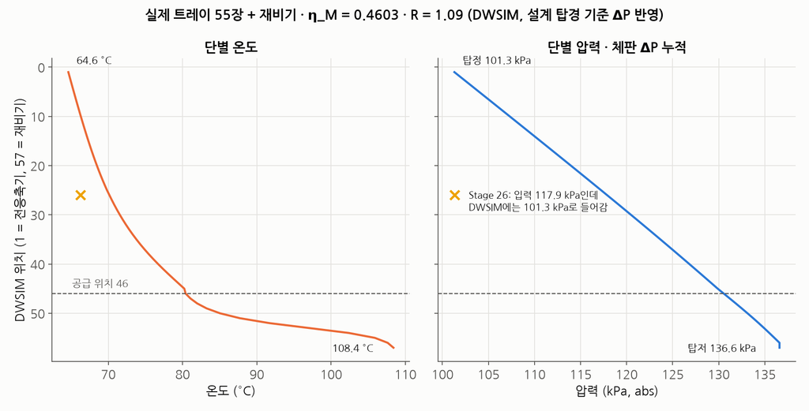

내부 트레이에 $\eta_M$ = 0.4603, 부분재비기는 평형단

| 실제 트레이 | 52 | 55 | 59 |
| --- | --- | --- | --- |
| DWSIM 위치 / 공급 | 54 / 43 | 57 / 46 | 61 / 49 |
| 총 ΔP 입력 → 재계산 (kPa) | 34.4 → 35.4 | 35.3 → 34.7 | 37.0 → 36.8 |
| 사양 충족 $R_D$ | 1.231 | 1.09 | 1.078 |
| $q_c$ (kW) | 8,782 | 8,228 | 8,180 |
| $q_r$ (kW) | 8,990 | 8,436 | 8,392 |

- 단당 ΔP: 세 경우 모두 설계 탑경 2.415 m (80 % 운전) 기준으로 단별 계산
- 정압 계산 → 압력 프로파일 입력 → 사양 미달 → $R_D$ 상향 → 재계산 ΔP와 4 % 이내 수렴
- 탑저 101.3 → 136–138 kPa, 99.7 → 108.3–108.8 °C: **ΔP가 탑저 온도·열부하를 올림**

55장 계산에서 Stage 26 압력이 입력값 117.9 kPa 대신 101.3 kPa로 들어감 (그림 ×) → 수정 후 $R_D$·열부하 재확인 필요

## 경제성 · TAC 비교 (3년 회수 기준)

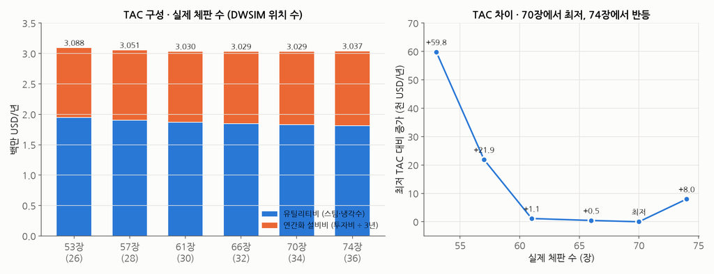

$\mathrm{TAC} = 0.0036 \times 8000\,(7.78\,q_r + 0.354\,q_c) + C_{capital}/3$ · 스팀 7.78 USD/GJ, 냉각수 0.354 USD/GJ, 8,000 h/년, CEPCI 397 (2001) → 878.2 (2026.7)

설비비: 탑 본체 + 탄소강 체판 + 고정관판형 응축기 + 케틀형 재비기 3기 (Javaloyes-Antón 등, Turton 등 상관식) · ΔP 반영 이론단 시뮬레이션 열부하 사용

## TAC 결과 해석

단위: M USD/년

| 체판 (장) | 위치 | $R_D$ | 유틸리티 | 설비비 ÷ 3 | TAC |
| --- | --- | --- | --- | --- | --- |
| 53 | 26 | 1.083 | 1.942 | 1.146 | 3.088 |
| 57 | 28 | 1.036 | 1.898 | 1.152 | 3.051 |
| 61 | 30 | 1.002 | 1.866 | 1.164 | 3.030 |
| 66 | 32 | 0.977 | 1.841 | 1.188 | 3.029 |
| **70** | **34** | **0.957** | **1.822** | **1.206** | **3.029** |
| 74 | 36 | 0.943 | 1.808 | 1.229 | 3.037 |

- 66 → 70장: 투자 +55,380 USD, 유틸리티 −18,920 USD/년 → 단순 회수 2.93년, TAC 차이 **460 USD/년 (0.015 %)**
- 70 → 74장: TAC **+7,995 USD/년 반등**

**교차 확인** · 다른 비용 기준 (Zhang 등 2018, β = 0.1/년, 8,500 h, 스팀 6 / 냉각수 1.5 USD/GJ), 효율 적용 DWSIM 열부하

| 실제 트레이 | 52 | 55 | 59 |
| --- | --- | --- | --- |
| 높이 (m) | 29.0 | 30.5 | 32.5 |
| 스팀 (M USD/년) | 1.651 | 1.549 | 1.541 |
| 냉각수 (M USD/년) | 0.403 | 0.378 | 0.375 |
| TAC (M USD/년) | 2.069 | 1.942 | **1.932** |

이 기준의 연간화 설비비는 TAC의 1 % 미만 → 사실상 유틸리티비 비교. 설비비 산정 방식이 달라 3년 기준 TAC와 절대값 비교 불가

## 최종 설계안

| 항목 | 설계값 |
| --- | --- |
| 형식 | 체판탑 (sieve tray), 탄소강 |
| 물성 모델 | UNIFAC |
| 탑정 압력 | 101.3 kPa(abs), 체판 ΔP 반영 |
| 이론단 | DWSIM 34 위치 (전응축기 + 32 + 재비기) |
| 실제 체판 | **70장** ($\eta_0$ = 0.4603), 간격 0.50 m |
| 탑경 / 높이 | **2.387 m / 37.0 m** |
| 환류비 | 0.957 |
| 투자비 | 3.62 M USD |
| TAC (3년) | **3.029 M USD/년** |

**대안** · 66장 (높이 35.0 m, 탑경 2.399 m): TAC 차이 연 460 USD → 사실상 동등, 높이 2 m 낮음

**규모 비교** · 인도네시아 바이오디젤 공장 메탄올–물 증류탑: 트레이 60장, 높이 35 m (Burmana 등 2025)

비용은 이론단 시뮬레이션 열부하 + 문헌 상관식 예비 추정치. 공급 예열·가압 비용 제외. 66·70장 후보에 효율 적용 DWSIM 사양 확인 필요.

## Other Considerations 적용 범위와 남은 과제

| 안내문 항목 | 이번 설계에서 다룬 내용 |
| --- | --- |
| Nonideal mixture | 실측 VLE, 4개 모델 비교 → UNIFAC |
| Pressure drop, flooding | Fair 상관식, 탑경, 단당 ΔP, froth height |
| Enthalpy balance | DWSIM 열수지, CMO 점검, $q_c$·$q_r$ |
| Efficiency | O’Connell, Murphree 유효 평형선 |
| Optimum parameters | 단수–환류비–열부하, TAC 최소 |
| Simulator | DWSIM Property Comparison, McCabe–Thiele, 엄밀 증류탑 |

**남은 과제**

- 66·70장 후보에 효율 + ΔP 적용 DWSIM 사양 확인
- 공급 예열 (탑저 110 °C 물과 열교환)로 $q_r$ 절감
- 실제 조메탄올의 다성분 (용존 CO₂, 경질분, 고급 알코올) 영향
- 충전탑 대안 (HETP, 압력강하 비교)

## 참고문헌

- McCabe, Smith, Harriott, *Unit Operations of Chemical Engineering*, Ch. 21 (Example 21.2, 21.6), Ch. 22 (Example 22.3); 강의자료 SeparationProcess 6–8
- Álvarez, V. H. 등 (2011), 메탄올–물 101.3 kPa VLE 실측, *Physics and Chemistry of Liquids*, doi:10.1080/00319100903012403
- NIST Chemistry WebBook — 메탄올, 물 물성 및 Antoine 계수
- IMPCA Methanol Reference Specifications (2024)
- IRENA & Methanol Institute (2021), *Innovation Outlook: Renewable Methanol*, https://www.irena.org/Publications/2021/Jan/Innovation-Outlook-Renewable-Methanol
- European Energy (2025.5.13), Kassø e-methanol facility officially inaugurated, https://europeanenergy.com/2025/05/13/kasso-e-methanol-facility-officially-inaugurated
- The Maritime Executive (2025.6), Maersk reaches milestone with delivery of 12th large methanol containership
- DWSIM documentation — Property Package Comparison, McCabe–Thiele, Rigorous Distillation Column, Fair entrainment flooding
- Wang 등 (2019), *Processes* 7(6) 323, Appendix A — TAC 계산 틀
- Zhang, S. 등 (2018), *Energy* 162, 1139–1157, Appendix C — TAC 계산
- Javaloyes-Antón 등, Appendix A; Turton 등; Di Pretoro 등 — 장비 비용 상관식
- Luyben, W. L. (2005), *Ind. Eng. Chem. Res.* 44(20), 7800–7813 — 총괄 전열계수
- Ramdin, M. 등 (2021), *Ind. Eng. Chem. Res.* 60(49), 17862 — 유틸리티 단가
- Burmana 등 (2025) — 바이오디젤 공장 메탄올–물 증류탑 운전 사례
- 팀 자료: https://github.com/NaNha77/Separation-Process-project